# R Text Analysis - day 2

```r
library(tidyverse)
library(tidytext)
library(tidymodels)
options(scipen = 999)
```

What is sentiment analysis?

In this notebook, we’re going to perform sentiment analysis on a dataset of tweets about US airlines. Sentiment analysis is the task of extracting affective states from text. Sentiment analysis is most ofen used to answer questions like:

- what do our customers think of us?
- do our users like the look of our product?
- what aspects of our service are users dissatisfied with?

Dataset

The dataset was collected by Crowdflower, which they then made public through Kaggle. I’ve downloaded it for you and put it in the “data” directory. Note that this is a nice clean dataset; not the norm in real-life data science! I’ve chosen this dataset so that we can concentrate on understanding what text classification is and how to do it.

```r
airline_tweets <- read_csv("data/tweets.csv")
```

Which airlines are tweeted about and how many of each in this dataset?

```r
airline_tweets %>%
  group_by(airline) %>%
  count(sort = T)
```

```
## # A tibble: 6 x 2
## # Groups:   airline [6]
##   airline            n
##   <chr>          <int>
## 1 United          3822
## 2 US Airways      2913
## 3 American        2759
## 4 Southwest       2420
## 5 Delta           2222
## 6 Virgin America   504
```

Challenge

- How many tweets are in the dataset?
- How many tweets are positive, neutral and negative?
- What proportion of tweets are positive, neutral and negative?
- Visualize these last two questions.

Extra challenge

- When did the tweets come from?
- Who gets more retweets: positive, negative or neutral tweets?
- What are the reasons why people tweet negatively? Show distribution.

there are a variety of methods and dictionaries that exist for evaluating the opinion or emotion in text. The tidytext package provides access to several sentiment lexicons. Three general-purpose lexicons are

- AFINN from Finn Årup Nielsen,
- bing from Bing Liu and collaborators, and
- nrc from Saif Mohammad and Peter Turney.

All three of these lexicons are based on unigrams, i.e., single words. These lexicons contain many English words and the words are assigned scores for positive/negative sentiment, and also possibly emotions like joy, anger, sadness, and so forth. The nrc lexicon categorizes words in a binary fashion (“yes”/“no”) into categories of positive, negative, anger, anticipation, disgust, fear, joy, sadness, surprise, and trust. The bing lexicon categorizes words in a binary fashion into positive and negative categories. The AFINN lexicon assigns words with a score that runs between -5 and 5, with negative scores indicating negative sentiment and positive scores indicating positive sentiment.

We can access these sentiment dictionaries via `tidytext`’s `get_sentiment()` function.

```r
get_sentiments("afinn")
```

```
## # A tibble: 2,477 x 2
##    word       value
##    <chr>      <dbl>
##  1 abandon       -2
##  2 abandoned     -2
##  3 abandons      -2
##  4 abducted      -2
##  5 abduction     -2
##  6 abductions    -2
##  7 abhor         -3
##  8 abhorred      -3
##  9 abhorrent     -3
## 10 abhors        -3
## # … with 2,467 more rows
```

```r
get_sentiments("bing")
```

```
## # A tibble: 6,786 x 2
##    word        sentiment
##    <chr>       <chr>
##  1 2-faces     negative
##  2 abnormal    negative
##  3 abolish     negative
##  4 abominable  negative
##  5 abominably  negative
##  6 abominate   negative
##  7 abomination negative
##  8 abort       negative
##  9 aborted     negative
## 10 aborts      negative
## # … with 6,776 more rows
```

```r
get_sentiments("nrc")
```

```
## # A tibble: 13,901 x 2
##    word        sentiment
##    <chr>       <chr>
##  1 abacus      trust
##  2 abandon     fear
##  3 abandon     negative
##  4 abandon     sadness
##  5 abandoned   anger
##  6 abandoned   fear
##  7 abandoned   negative
##  8 abandoned   sadness
##  9 abandonment anger
## 10 abandonment fear
## # … with 13,891 more rows
```

With data in a tidy format, sentiment analysis can be done with an `inner_join()`. This is another of the great successes of viewing text mining as a tidy data analysis task; much as removing stop words wtih `anti_join()`.

```r
twitter_handle_pattern <-  "@(\\w+)"
url_pattern <- "https?:\\/\\/.*[\r\n]*"
hashtag_pattern <- "(?:^|\\s)[＃#]{1}(\\w+)"
digit_pattern <- "\\d+"

time_of_day_pattern <- "(\\d+:\\d+:\\d+.-\\d+)"
```

```r
at_df_clean <- airline_tweets %>%
  mutate(text = str_remove_all(text, twitter_handle_pattern),
         text = str_remove_all(text, url_pattern),
         text = str_remove_all(text, hashtag_pattern),
         text = str_remove_all(text, digit_pattern),
         text = str_remove_all(text, "[[:punct:]]"),
         tweet_created = str_remove_all(tweet_created, time_of_day_pattern),
         tweet_created = as.Date(tweet_created))

at_df_clean %>% select(text)
```

```
## # A tibble: 14,640 x 1
##    text
##    <chr>
##  1 " What  said"
##  2 " plus youve added commercials to the experience tacky"
##  3 " I didnt today Must mean I need to take another trip"
##  4 " its really aggressive to blast obnoxious entertainment in your guests face…
##  5 " and its a really big bad thing about it"
##  6 " seriously would pay $ a flight for seats that didnt have this playing\nits…
##  7 " yes nearly every time I fly VX this ear worm wont go away "
##  8 " Really missed a prime opportunity for Men Without Hats parody there "
##  9 " Well I didntbut NOW I DO D"
## 10 " it was amazing and arrived an hour early Youre too good to me"
## # … with 14,630 more rows
```

```r
at_df_tokens <- at_df_clean %>%
  unnest_tokens(word, text) %>%
  inner_join(get_sentiments("afinn"), by = "word") %>%
  group_by(tweet_created, airline) %>%
  summarise(sentiment = sum(value))

at_df_tokens
```

```
## # A tibble: 47 x 3
## # Groups:   tweet_created [9]
##    tweet_created airline        sentiment
##    <date>        <chr>              <dbl>
##  1 2015-02-16    Delta                  0
##  2 2015-02-16    United                 1
##  3 2015-02-17    Delta                273
##  4 2015-02-17    Southwest            209
##  5 2015-02-17    United                34
##  6 2015-02-17    US Airways            36
##  7 2015-02-17    Virgin America        49
##  8 2015-02-18    Delta                299
##  9 2015-02-18    Southwest            223
## 10 2015-02-18    United               147
## # … with 37 more rows
```

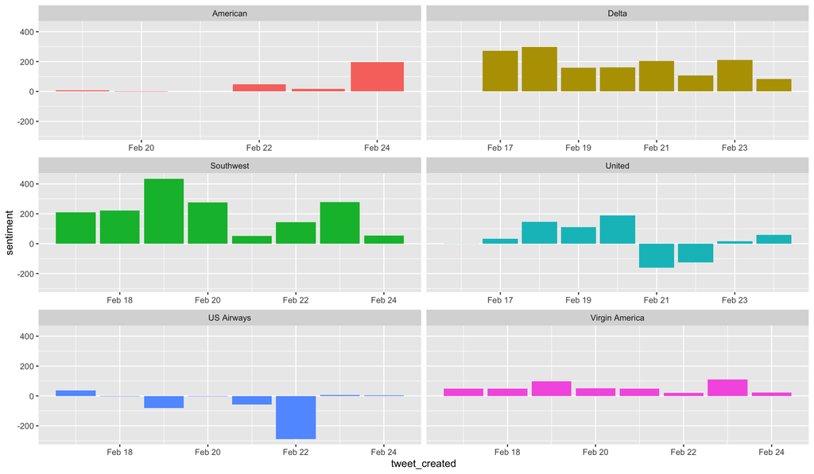

```r
ggplot(at_df_tokens, aes(tweet_created, sentiment, fill = airline)) +
  geom_col(show.legend = FALSE) +
  facet_wrap(~airline, ncol = 2, scales = "free_x")
```

## 0.1 Classification

### 0.1.1 Logistic regression with binary class

To understand the theoretical gist of our classification task, let’s first focus on a binary ‘positive vs negative’ classifier. We are going to do so by restricting the analysis to the non-neutral tweets.

```r
at_classify <- airline_tweets %>%
  filter(airline_sentiment != "neutral")
```

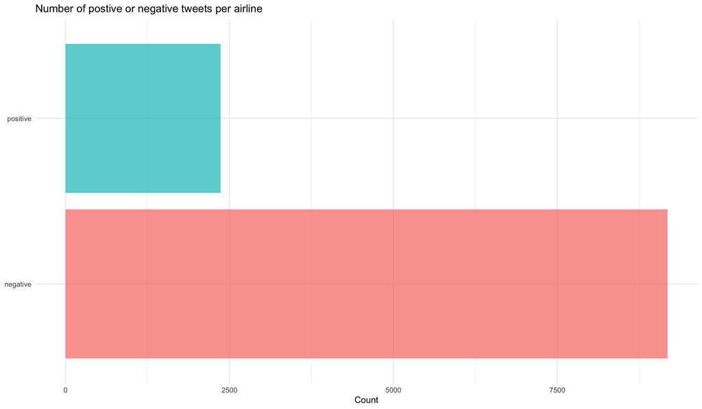

```r
at_classify %>%
ggplot(aes(airline_sentiment, fill = airline_sentiment)) +
  geom_bar(alpha = .7) +
  coord_flip() +
  theme_minimal() +
  theme(legend.position="none") +
  labs(x = NULL,
       y = "Count",
       title = "Number of postive or negative tweets per airline")
```

There’s a severe class imbalance here. But let’s continue anyways…

# 1 Bag of words and DTM

```r
at_classify_clean <- at_classify %>%
  select(text, airline_sentiment) %>%
  mutate(text = str_remove_all(text, twitter_handle_pattern),
         text = str_remove_all(text, url_pattern),
         text = str_remove_all(text, hashtag_pattern),
          text = str_remove_all(text, digit_pattern),
          text = str_remove_all(text, "[[:punct:]]"))

at_classify_clean %>% select(text)
```

```
## # A tibble: 11,541 x 1
##    text
##    <chr>
##  1 " plus youve added commercials to the experience tacky"
##  2 " its really aggressive to blast obnoxious entertainment in your guests face…
##  3 " and its a really big bad thing about it"
##  4 " seriously would pay $ a flight for seats that didnt have this playing\nits…
##  5 " yes nearly every time I fly VX this ear worm wont go away "
##  6 " Well I didntbut NOW I DO D"
##  7 " it was amazing and arrived an hour early Youre too good to me"
##  8 " I lt pretty graphics so much better than minimal iconography D"
##  9 " This is such a great deal Already thinking about my nd trip to  amp I have…
## 10 "  Im flying your skies again U take all the away from travel "
## # … with 11,531 more rows
```

```r
set.seed(94706)

at_split <- initial_split(at_classify_clean,
                          strata = "airline_sentiment")

train_data <- training(at_split)
test_data <- testing(at_split)
```

https://www.emilhvitfeldt.com/post/2018-12-29-text-classification-with-tidymodels/

```r
library(textrecipes)
```

```r
at_rec <- recipe(airline_sentiment ~., data = train_data) %>%
  step_filter(text != "") %>%
  step_tokenize(text) %>%
  step_tokenfilter(text, min_times = 11) %>%
  step_tf(text) %>%
  prep(training = train_data)

at_rec
```

```
## Recipe
##
## Inputs:
##
##       role #variables
##    outcome          1
##  predictor          1
##
## Training data contained 8655 data points and no missing data.
##
## Operations:
##
## Row filtering [trained]
## Tokenization for text [trained]
## Text filtering for text [trained]
## Term frequency with text [trained]
```

```r
at_train_data <- juice(at_rec)
at_test_data <- bake(at_rec, test_data)

str(at_train_data, list.len = 10)
```

```
## tibble [8,655 × 101] (S3: tbl_df/tbl/data.frame)
##  $ airline_sentiment: Factor w/ 2 levels "negative","positive": 1 1 1 1 1 1 1 1 1 1 ...
##  $ tf_text_a        : num [1:8655] 1 1 0 0 0 0 0 1 1 0 ...
##  $ tf_text_about    : num [1:8655] 1 1 0 0 0 0 0 0 0 1 ...
##  $ tf_text_after    : num [1:8655] 0 0 0 0 0 0 0 0 0 0 ...
##  $ tf_text_again    : num [1:8655] 0 0 0 0 0 0 0 0 0 0 ...
##  $ tf_text_airline  : num [1:8655] 0 0 0 0 0 0 0 0 0 0 ...
##  $ tf_text_all      : num [1:8655] 0 0 0 0 0 0 0 0 0 0 ...
##  $ tf_text_am       : num [1:8655] 0 0 0 0 0 0 0 0 0 0 ...
##  $ tf_text_amp      : num [1:8655] 0 0 0 0 0 0 0 0 0 1 ...
##  $ tf_text_an       : num [1:8655] 0 0 0 0 0 0 0 0 0 0 ...
##   [list output truncated]
```

https://juliasilge.com/blog/palmer-penguins/

```r
glm_model <- logistic_reg() %>%
  set_engine("glm")
glm_model
```

```
## Logistic Regression Model Specification (classification)
##
## Computational engine: glm
```

```r
at_model <- glm_model %>%
  fit(airline_sentiment ~ ., data = at_train_data)
```

```r
eval_tibble <- at_test_data %>%
  select(airline_sentiment) %>%
  mutate(
    class_at = parsnip:::predict_class(at_model, at_test_data),
    prop_at = parsnip:::predict_classprob(at_model, at_test_data))

accuracy(eval_tibble, truth = airline_sentiment, estimate = class_at)
```

```
## # A tibble: 1 x 3
##   .metric  .estimator .estimate
##   <chr>    <chr>          <dbl>
## 1 accuracy binary         0.852
```

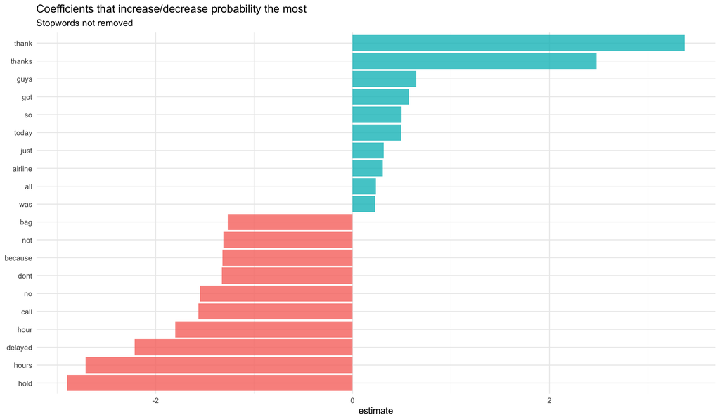

```r
at_model$fit %>%
  tidy() %>%
  mutate(term = str_replace(term, "tf_text_", "")) %>%
  group_by(estimate > 0) %>%
  top_n(10, abs(estimate)) %>%
  ungroup() %>%
  ggplot(aes(fct_reorder(term, estimate), estimate, fill = estimate > 0)) +
  geom_col(alpha = 0.8, show.legend = FALSE) +
  coord_flip() +
  theme_minimal() +
  labs(x = NULL,
  title = "Coefficients that increase/decrease probability the most",
  subtitle = "Stopwords not removed")
```

Because of how we transformed the **words** of tweets into **features** of our classification model, maybe it was better to keep the stop words in for context? I’ll leave that question to you, and strongly recommend exploring ML with Tidymodels workshop for how to find more advanced approaches to Maching Learning models and methods to tune them up better.